# Analyse complète — Avis Abritel (3 sources)

## 4. Distributions univariées

Histogrammes / barres : **notes**, **catégories**, **gravité**, **source**.

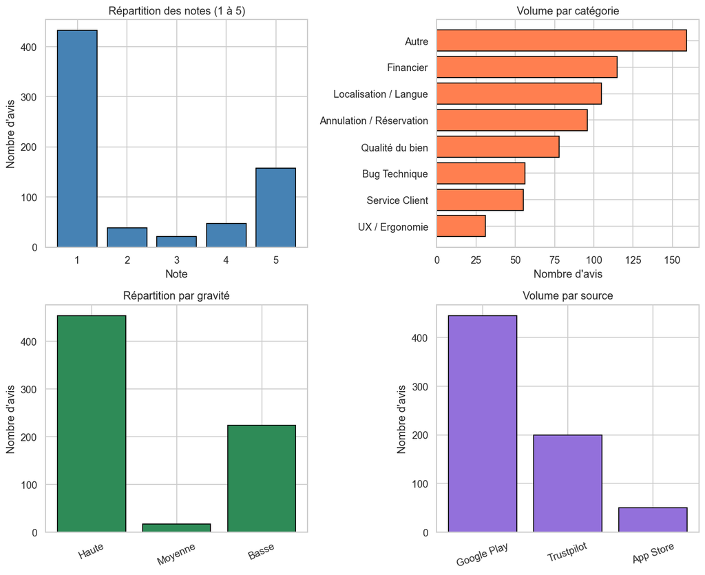

|  | Catégorie | Effectif | % du total |
| --- | --- | --- | --- |
| 0 | Autre | 159 | 22.88 |
| 1 | Financier | 115 | 16.55 |
| 2 | Localisation / Langue | 105 | 15.11 |
| 3 | Annulation / Réservation | 96 | 13.81 |
| 4 | Qualité du bien | 78 | 11.22 |
| 5 | Bug Technique | 56 | 8.06 |
| 6 | Service Client | 55 | 7.91 |
| 7 | UX / Ergonomie | 31 | 4.46 |

```python
fig, axes = plt.subplots(2, 2, figsize=(11, 9))

# Notes (échelle 1 à 5)
note_counts = df["note"].value_counts().reindex(ORDRE_NOTES, fill_value=0)
axes[0, 0].bar(
    note_counts.index.astype(str), note_counts.values, color="steelblue", edgecolor="black"
)
axes[0, 0].set_title("Répartition des notes (1 à 5)")
axes[0, 0].set_xlabel("Note")
axes[0, 0].set_ylabel("Nombre d'avis")

# Catégories (tri par effectif décroissant)
cat_counts = df["Catégorie"].value_counts()
axes[0, 1].barh(cat_counts.index[::-1], cat_counts.values[::-1], color="coral", edgecolor="black")
axes[0, 1].set_title("Volume par catégorie")
axes[0, 1].set_xlabel("Nombre d'avis")

# Gravité (ordre métier fixe : Haute → Moyenne → Basse)
g_full = df["Gravité"].value_counts().reindex(ORDRE_GRAVITE, fill_value=0)
axes[1, 0].bar(g_full.index, g_full.values, color="seagreen", edgecolor="black")
axes[1, 0].set_title("Répartition par gravité")
axes[1, 0].set_ylabel("Nombre d'avis")
axes[1, 0].tick_params(axis="x", rotation=25)

# Source
src_counts = df["source"].value_counts()
axes[1, 1].bar(
    src_counts.index.astype(str), src_counts.values, color="mediumpurple", edgecolor="black"
)
axes[1, 1].set_title("Volume par source")
axes[1, 1].set_ylabel("Nombre d'avis")
axes[1, 1].tick_params(axis="x", rotation=20)

plt.tight_layout()
plt.show()

# Table des fréquences (pour copier vers Excel / Power BI)
freq_table = pd.DataFrame(
    {
        "Catégorie": cat_counts.index,
        "Effectif": cat_counts.values,
        "% du total": (100 * cat_counts.values / N).round(2),
    }
)
freq_table
```

## 5. Analyse temporelle

Agrégation par **mois calendaire** (année-mois). Attention : les avis reflètent la date côté store, pas la date de scraping.

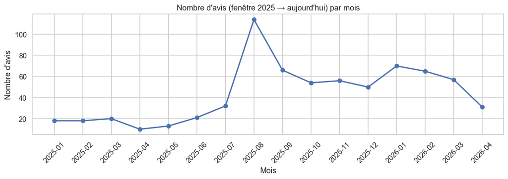

|  | annee_mois | nb_avis |
| --- | --- | --- |
| 0 | 2025-01 | 18 |
| 1 | 2025-02 | 18 |
| 2 | 2025-03 | 20 |
| 3 | 2025-04 | 10 |
| 4 | 2025-05 | 13 |
| 5 | 2025-06 | 21 |
| 6 | 2025-07 | 32 |
| 7 | 2025-08 | 114 |
| 8 | 2025-09 | 66 |
| 9 | 2025-10 | 54 |
| 10 | 2025-11 | 56 |
| 11 | 2025-12 | 50 |
| 12 | 2026-01 | 70 |
| 13 | 2026-02 | 65 |
| 14 | 2026-03 | 57 |
| 15 | 2026-04 | 31 |

```python
df_time = df.dropna(subset=["date"]).copy()
df_time["annee_mois"] = df_time["date"].dt.to_period("M").astype(str)

par_mois = df_time.groupby("annee_mois", as_index=False).size()
par_mois = par_mois.rename(columns={"size": "nb_avis"})

fig, ax = plt.subplots(figsize=(11, 4))
ax.plot(par_mois["annee_mois"], par_mois["nb_avis"], marker="o", linewidth=2, markersize=6)
ax.set_title("Nombre d'avis (fenêtre 2025 → aujourd'hui) par mois")
ax.set_xlabel("Mois")
ax.set_ylabel("Nombre d'avis")
ax.tick_params(axis="x", rotation=45)
plt.tight_layout()
plt.show()

par_mois
```

## 6. Tableau croisé Catégorie × Gravité

- **Effectifs** : combinaisons observées.
- **% par ligne** : répartition de la gravité *au sein* de chaque catégorie (utile pour prioriser).
- **% du total** : contribution de chaque cellule à l'ensemble.

```python
ct = pd.crosstab(df["Catégorie"], df["Gravité"], margins=True, margins_name="Total")
ct
```

| Gravité Catégorie | Basse | Haute | Moyenne | Total |
| --- | --- | --- | --- | --- |
| Annulation / Réservation | 0 | 96 | 0 | 96 |
| Autre | 138 | 17 | 4 | 159 |
| Bug Technique | 10 | 46 | 0 | 56 |
| Financier | 12 | 103 | 0 | 115 |
| Localisation / Langue | 8 | 91 | 6 | 105 |
| Qualité du bien | 41 | 34 | 3 | 78 |
| Service Client | 9 | 46 | 0 | 55 |
| UX / Ergonomie | 6 | 21 | 4 | 31 |
| Total | 224 | 454 | 17 | 695 |

```
% de chaque gravité DANS chaque catégorie (ligne = 100%) :
```

| Gravité Catégorie | Basse | Haute | Moyenne | Total ligne (100%) |
| --- | --- | --- | --- | --- |
| Annulation / Réservation | 0 | 100 | 0 | 100 |
| Autre | 86.79 | 10.69 | 2.52 | 100 |
| Bug Technique | 17.86 | 82.14 | 0 | 100 |
| Financier | 10.43 | 89.57 | 0 | 100 |
| Localisation / Langue | 7.62 | 86.67 | 5.71 | 100 |
| Qualité du bien | 52.56 | 43.59 | 3.85 | 100 |
| Service Client | 16.36 | 83.64 | 0 | 100 |
| UX / Ergonomie | 19.35 | 67.74 | 12.9 | 99.99 |

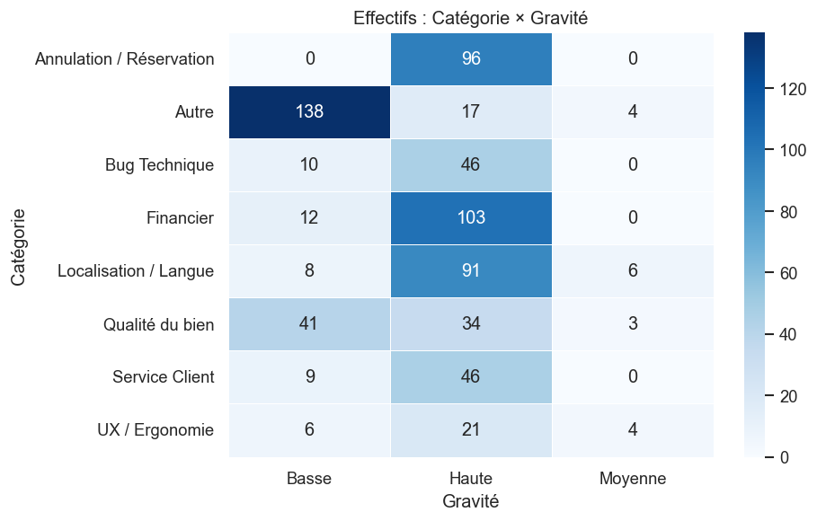

```python
# % par ligne (sans la ligne Total pour le calcul)
ct_body = pd.crosstab(df["Catégorie"], df["Gravité"])
pct_ligne = ct_body.div(ct_body.sum(axis=1), axis=0) * 100
pct_ligne = pct_ligne.round(2)
pct_ligne["Total ligne (100%)"] = pct_ligne.sum(axis=1).round(2)
print("% de chaque gravité DANS chaque catégorie (ligne = 100%) :")
display(pct_ligne)

# Heatmap des effectifs
plt.figure(figsize=(8, 5))
sns.heatmap(ct_body, annot=True, fmt="d", cmap="Blues", linewidths=0.5)
plt.title("Effectifs : Catégorie × Gravité")
plt.ylabel("Catégorie")
plt.xlabel("Gravité")
plt.tight_layout()
plt.show()
```

## 7. Note selon la catégorie

Boîtes à moustaches : distribution des **notes (1–5)** par catégorie (les médianes aident à comparer l’intensité du score, pas seulement le volume).

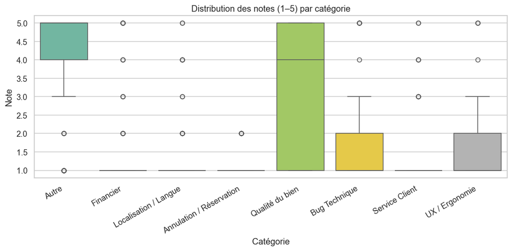

| Catégorie | count | mean | median | std |
| --- | --- | --- | --- | --- |
| Annulation / Réservation | 96 | 1.073 | 1 | 0.261 |
| Autre | 159 | 4.27 | 5 | 1.311 |
| Bug Technique | 56 | 1.75 | 1 | 1.311 |
| Financier | 115 | 1.417 | 1 | 1.092 |
| Localisation / Langue | 105 | 1.286 | 1 | 0.84 |
| Qualité du bien | 78 | 2.974 | 4 | 1.858 |
| Service Client | 55 | 1.455 | 1 | 1.086 |
| UX / Ergonomie | 31 | 1.742 | 1 | 1.316 |

```python
ordre_cat = df["Catégorie"].value_counts().index.tolist()
plt.figure(figsize=(10, 5))
sns.boxplot(data=df, x="Catégorie", y="note", order=ordre_cat, palette="Set2")
plt.title("Distribution des notes (1–5) par catégorie")
plt.xlabel("Catégorie")
plt.ylabel("Note")
plt.xticks(rotation=30, ha="right")
plt.tight_layout()
plt.show()

df.groupby("Catégorie", observed=True)["note"].agg(["count", "mean", "median", "std"]).round(3)
```

## 8. Longueur des commentaires (proxy d’effort / détail)

Nombre de caractères (et de mots) par avis : utile pour détecter des avis « courts » vs « argumentés ». Corrélation de **Spearman** entre longueur et note (ordinales) — interprétation prudente.

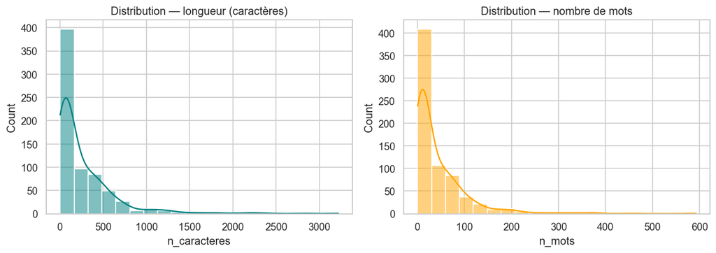

```
Corrélation de Spearman (caractères vs note) : -0.5895
```

| Catégorie | n_caracteres | n_mots |
| --- | --- | --- |
| Annulation / Réservation | 423 | 69 |
| Autre | 23 | 4 |
| Bug Technique | 79.5 | 13.5 |
| Financier | 353 | 62 |
| Localisation / Langue | 143 | 24 |
| Qualité du bien | 111 | 20 |
| Service Client | 228 | 41 |
| UX / Ergonomie | 42 | 8 |

```python
df["n_caracteres"] = df["texte"].str.len()
df["n_mots"] = df["texte"].str.split().str.len()

fig, axes = plt.subplots(1, 2, figsize=(11, 4))
sns.histplot(df["n_caracteres"], bins=20, kde=True, ax=axes[0], color="teal")
axes[0].set_title("Distribution — longueur (caractères)")
sns.histplot(df["n_mots"], bins=20, kde=True, ax=axes[1], color="orange")
axes[1].set_title("Distribution — nombre de mots")
plt.tight_layout()
plt.show()

# Spearman : monotone entre longueur et note
rho = df[["n_caracteres", "note"]].corr(method="spearman").iloc[0, 1]
print(f"Corrélation de Spearman (caractères vs note) : {rho:.4f}")

df.groupby("Catégorie", observed=True)[["n_caracteres", "n_mots"]].median().round(1)
```

## 9. Courbe de Pareto (catégories)

Les **k** premières catégories cumulent quelle part du volume ? Aide à trancher « vital few » en revue produit.

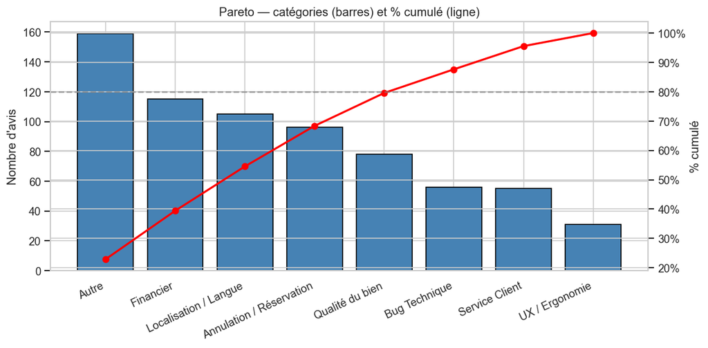

|  | Catégorie | Effectif | % cumulé |
| --- | --- | --- | --- |
| 0 | Autre | 159 | 22.88 |
| 1 | Financier | 115 | 39.42 |
| 2 | Localisation / Langue | 105 | 54.53 |
| 3 | Annulation / Réservation | 96 | 68.35 |
| 4 | Qualité du bien | 78 | 79.57 |
| 5 | Bug Technique | 56 | 87.63 |
| 6 | Service Client | 55 | 95.54 |
| 7 | UX / Ergonomie | 31 | 100 |

```python
cat_sorted = df["Catégorie"].value_counts().sort_values(ascending=False)
cum_pct = (100 * cat_sorted.cumsum() / N).round(2)

pareto = pd.DataFrame(
    {"Catégorie": cat_sorted.index, "Effectif": cat_sorted.values, "% cumulé": cum_pct.values}
)

fig, ax1 = plt.subplots(figsize=(10, 5))
x = np.arange(len(cat_sorted))
ax1.bar(x, cat_sorted.values, color="steelblue", edgecolor="black", label="Effectif")
ax1.set_xticks(x)
ax1.set_xticklabels(cat_sorted.index, rotation=25, ha="right")
ax1.set_ylabel("Nombre d'avis")
ax1.set_title("Pareto — catégories (barres) et % cumulé (ligne)")

ax2 = ax1.twinx()
ax2.plot(x, cum_pct.values, color="red", marker="o", linewidth=2, label="% cumulé")
ax2.set_ylabel("% cumulé")
ax2.yaxis.set_major_formatter(mtick.PercentFormatter(xmax=100))
ax2.axhline(80, color="gray", linestyle="--", alpha=0.7, label="80 %")
fig.tight_layout()
plt.show()

pareto
```

## 10. Comparaison inter-sources

Les trois sources (Google Play, App Store, Trustpilot) attirent-elles le même profil de plainte ? Test de **Kruskal-Wallis** (non paramétrique, données ordinales) pour comparer les distributions de notes entre sources.

```
Kruskal-Wallis H = 190.992, p = 0.0000
→ Distributions significativement différentes (p < 0.05)
```

| source | N avis | Moyenne | Médiane | Écart-type |
| --- | --- | --- | --- | --- |
| App Store | 50 | 1.26 | 1 | 0.633 |
| Google Play | 445 | 2.874 | 2 | 1.819 |
| Trustpilot | 200 | 1.01 | 1 | 0.1 |

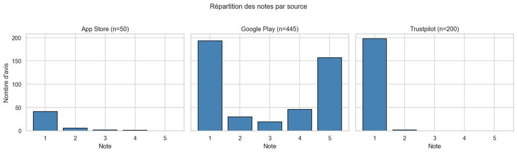

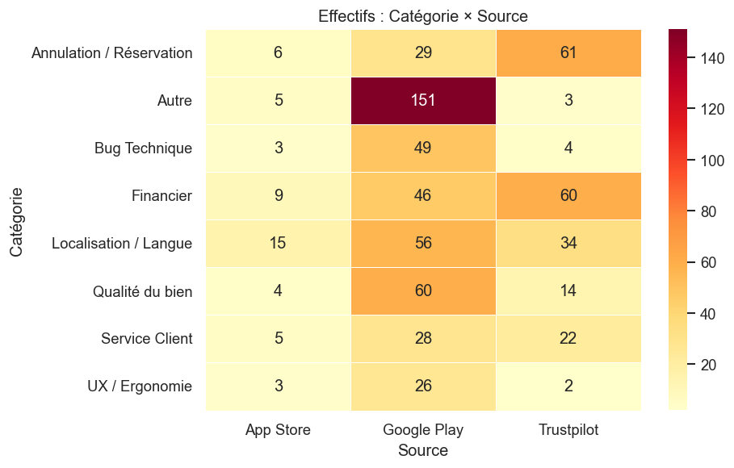

```python
from scipy.stats import chi2_contingency, kendalltau, kruskal

# Kruskal-Wallis : notes par source
groups = [g["note"].dropna().values for _, g in df.groupby("source")]
stat, p = kruskal(*groups)
print(f"Kruskal-Wallis H = {stat:.3f}, p = {p:.4f}")
print(
    "→",
    "Distributions significativement différentes (p < 0.05)"
    if p < 0.05
    else "Pas de différence significative",
)
print()

# KPIs par source
src_stats = df.groupby("source")["note"].agg(["count", "mean", "median", "std"]).round(3)
src_stats.columns = ["N avis", "Moyenne", "Médiane", "Écart-type"]
display(src_stats)

# Distribution des notes par source
fig, axes = plt.subplots(1, 3, figsize=(14, 4), sharey=True)
for ax, (source, grp) in zip(axes, df.groupby("source"), strict=False):
    counts = grp["note"].value_counts().reindex(ORDRE_NOTES, fill_value=0)
    ax.bar(counts.index.astype(str), counts.values, color="steelblue", edgecolor="black")
    ax.set_title(f"{source} (n={len(grp)})")
    ax.set_xlabel("Note")
axes[0].set_ylabel("Nombre d'avis")
plt.suptitle("Répartition des notes par source", fontsize=13, y=1.02)
plt.tight_layout()
plt.show()

# Catégories par source (heatmap)
ct_src = pd.crosstab(df["Catégorie"], df["source"])
plt.figure(figsize=(8, 5))
sns.heatmap(ct_src, annot=True, fmt="d", cmap="YlOrRd", linewidths=0.5)
plt.title("Effectifs : Catégorie × Source")
plt.ylabel("Catégorie")
plt.xlabel("Source")
plt.tight_layout()
plt.show()
```

## 11. Analyse textuelle (fréquences de mots)

Mots les plus fréquents (hors stopwords français), comparaison **1★ vs 5★**, et mots distinctifs par catégorie.

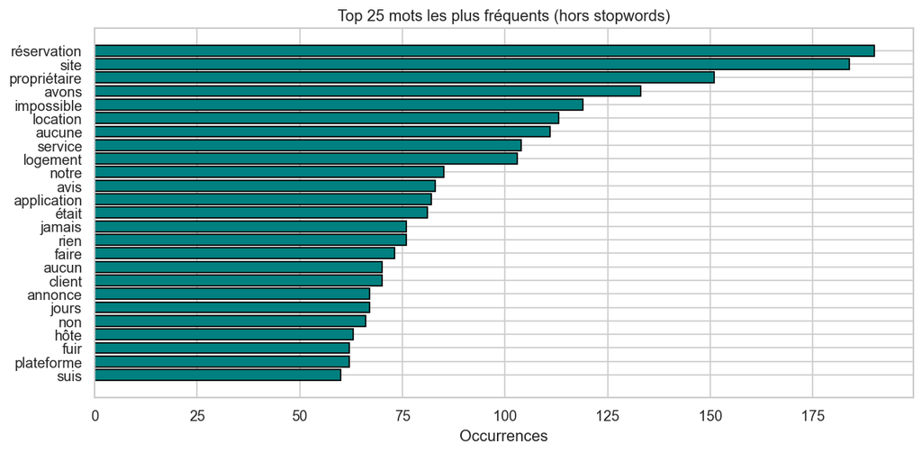

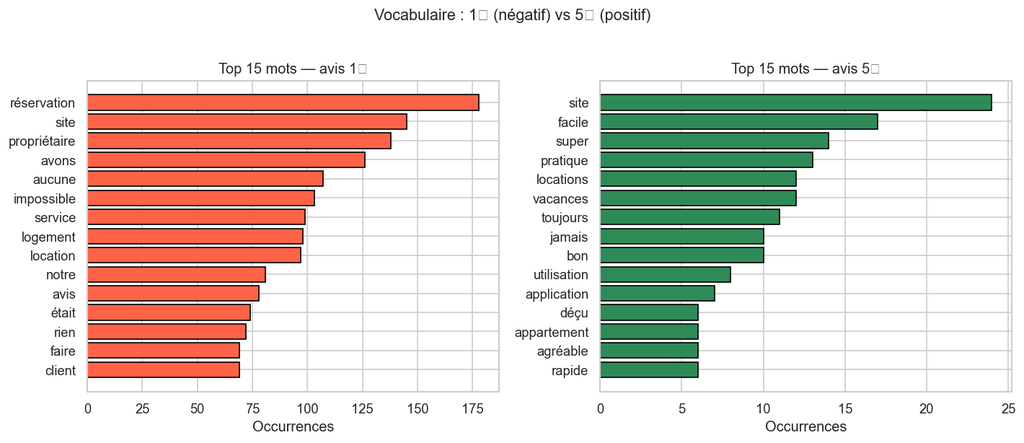

```python
import re
from collections import Counter

_STOPWORDS_FR = {
    "de",
    "la",
    "le",
    "les",
    "des",
    "du",
    "un",
    "une",
    "et",
    "en",
    "est",
    "que",
    "qui",
    "dans",
    "pour",
    "pas",
    "plus",
    "par",
    "sur",
    "au",
    "aux",
    "ce",
    "se",
    "son",
    "sa",
    "ses",
    "mon",
    "ma",
    "mes",
    "nous",
    "vous",
    "ils",
    "je",
    "on",
    "ne",
    "avec",
    "très",
    "tout",
    "été",
    "mais",
    "ou",
    "si",
    "il",
    "elle",
    "a",
    "ai",
    "y",
    "à",
    "d",
    "l",
    "n",
    "s",
    "qu",
    "c",
    "j",
    "m",
    "t",
    "bien",
    "fait",
    "sans",
    "cette",
    "sont",
    "ont",
    "être",
    "avoir",
    "même",
    "peut",
    "entre",
    "aussi",
    "tous",
    "après",
    "avant",
    "ça",
    "nos",
    "leur",
    "comme",
    "car",
    "donc",
    "ni",
    "dont",
    "quand",
    "peu",
    "où",
    "fois",
    "commentaire",
    "abritel",
}


def _tokenize(text: str) -> list[str]:
    return [
        w
        for w in re.findall(r"[a-zàâäéèêëïîôùûüçœæ]+", text.lower())
        if len(w) > 2 and w not in _STOPWORDS_FR
    ]


# Top 25 mots globaux
all_words = Counter()
for t in df["texte"]:
    all_words.update(_tokenize(t))

top25 = all_words.most_common(25)
mots, freqs = list(zip(*top25, strict=True))

plt.figure(figsize=(10, 5))
plt.barh(list(reversed(mots)), list(reversed(freqs)), color="teal", edgecolor="black")
plt.title("Top 25 mots les plus fréquents (hors stopwords)")
plt.xlabel("Occurrences")
plt.tight_layout()
plt.show()


# Comparaison 1★ vs 5★
def _top_words(mask, n=15):
    c = Counter()
    for t in df.loc[mask, "texte"]:
        c.update(_tokenize(t))
    return c.most_common(n)


fig, axes = plt.subplots(1, 2, figsize=(12, 5))
for ax, note_val, color in [(axes[0], 1, "tomato"), (axes[1], 5, "seagreen")]:
    tw = _top_words(df["note"] == note_val, 15)
    if tw:
        m, f = list(zip(*tw, strict=True))
        ax.barh(list(reversed(m)), list(reversed(f)), color=color, edgecolor="black")
    ax.set_title(f"Top 15 mots — avis {note_val}★")
    ax.set_xlabel("Occurrences")
plt.suptitle("Vocabulaire : 1★ (négatif) vs 5★ (positif)", fontsize=13, y=1.02)
plt.tight_layout()
plt.show()
```

## 12. Test d'indépendance Catégorie × Gravité (χ²)

Un test du **chi-deux** vérifie si la gravité dépend de la catégorie (H₀ : indépendance). La heatmap des **résidus de Pearson** montre quelles cellules contribuent le plus à l'écart avec l'hypothèse d'indépendance.

```
Chi² = 379.83,  ddl = 14,  p-value = 0.0000
→ Dépendance significative (p < 0.05) : la gravité varie selon la catégorie
```

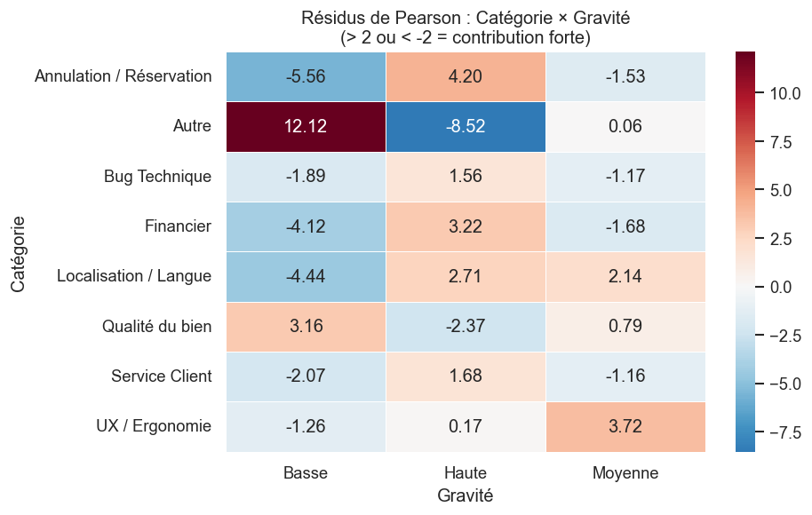

```python
ct_test = pd.crosstab(df["Catégorie"], df["Gravité"])
chi2, p, dof, expected = chi2_contingency(ct_test)
print(f"Chi² = {chi2:.2f},  ddl = {dof},  p-value = {p:.4f}")
print(
    "→",
    "Dépendance significative (p < 0.05) : la gravité varie selon la catégorie"
    if p < 0.05
    else "Pas de dépendance significative",
)

# Résidus de Pearson : (observé - attendu) / √attendu
residuals = (ct_test.values - expected) / np.sqrt(expected)
res_df = pd.DataFrame(residuals, index=ct_test.index, columns=ct_test.columns)

plt.figure(figsize=(8, 5))
sns.heatmap(res_df, annot=True, fmt=".2f", cmap="RdBu_r", center=0, linewidths=0.5)
plt.title("Résidus de Pearson : Catégorie × Gravité\n(> 2 ou < -2 = contribution forte)")
plt.ylabel("Catégorie")
plt.xlabel("Gravité")
plt.tight_layout()
plt.show()
```

## 13. Tendance temporelle et test de tendance

- **Moyenne mobile 30 jours** de la note : la satisfaction évolue-t-elle ?
- **Volume mensuel par gravité** (aire empilée).
- **Test de Kendall τ** : tendance monotone significative de la note moyenne mensuelle ?

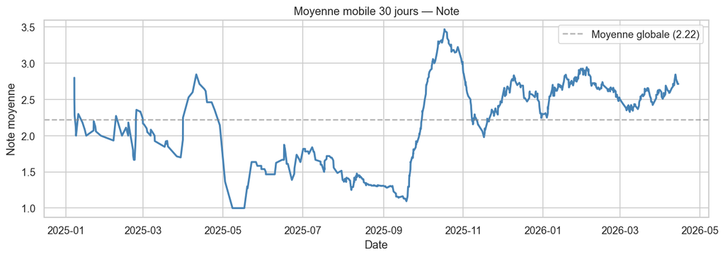

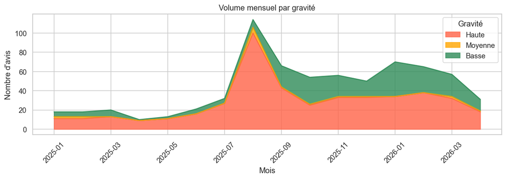

```
Kendall τ = 0.4000,  p = 0.0326
→ Tendance significative à la hausse
```

```python
# Moyenne mobile 30 jours
df_sorted = df.dropna(subset=["date", "note"]).sort_values("date").copy()
df_sorted = df_sorted.set_index("date")
rolling_mean = df_sorted["note"].rolling("30D", min_periods=5).mean()

fig, ax = plt.subplots(figsize=(11, 4))
ax.plot(rolling_mean.index, rolling_mean.values, color="steelblue", linewidth=2)
ax.axhline(
    df["note"].mean(),
    color="gray",
    linestyle="--",
    alpha=0.6,
    label=f"Moyenne globale ({df['note'].mean():.2f})",
)
ax.set_title("Moyenne mobile 30 jours — Note")
ax.set_ylabel("Note moyenne")
ax.set_xlabel("Date")
ax.legend()
plt.tight_layout()
plt.show()

# Volume mensuel par gravité (aire empilée)
df_time2 = df.dropna(subset=["date"]).copy()
df_time2["mois"] = df_time2["date"].dt.to_period("M").astype(str)
pivot_grav = df_time2.groupby(["mois", "Gravité"]).size().unstack(fill_value=0)
pivot_grav = pivot_grav.reindex(columns=ORDRE_GRAVITE, fill_value=0)

fig, ax = plt.subplots(figsize=(11, 4))
pivot_grav.plot.area(ax=ax, color=["tomato", "orange", "seagreen"], alpha=0.8)
ax.set_title("Volume mensuel par gravité")
ax.set_ylabel("Nombre d'avis")
ax.set_xlabel("Mois")
ax.tick_params(axis="x", rotation=45)
ax.legend(title="Gravité")
plt.tight_layout()
plt.show()

# Test de tendance : Kendall τ sur note moyenne mensuelle
monthly_mean = df_time2.groupby("mois")["note"].mean()
tau, p_tau = kendalltau(range(len(monthly_mean)), monthly_mean.values)
print(f"Kendall τ = {tau:.4f},  p = {p_tau:.4f}")
if p_tau < 0.05:
    direction = "hausse" if tau > 0 else "baisse"
    print(f"→ Tendance significative à la {direction}")
else:
    print("→ Pas de tendance monotone significative")
```

## 14. Deep dive : 1★ vs 5★

Comparaison des catégories, de la longueur de texte et échantillons qualitatifs entre les extrêmes.

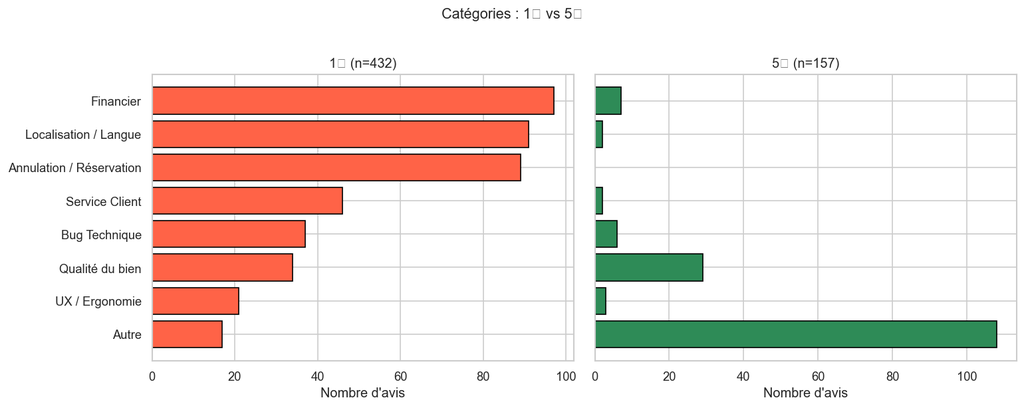

```
Longueur du texte par note :
```

| note | Moyenne (car.) | Médiane (car.) |
| --- | --- | --- |
| 1 | 375.3 | 285.5 |
| 2 | 179.4 | 87.5 |
| 3 | 173.2 | 126 |
| 4 | 69.4 | 55 |
| 5 | 51.2 | 27 |

```
--- 5 avis 1★ (échantillon aléatoire) ---
  [Google Play] Application en anglais et les prix en nzd.......pas grave, il y a d'autres sites plus conviviaux

  [Trustpilot] Service client lamentable. Service client lamentable
Au téléphone, les interlocuteurs ne maîtrisent pas le français et ne comprennent pas vos question

  [Trustpilot] Une horreur !. Une horreur !

Double réservation , logement annulé , vacances gâchées et impossible de se faire rembourser

site de réservation à fui

  [App Store] Inutilisable sur mon IPad. L’application s’installe systématiquement en Anglais alors que ma langue système est le Français et en plus on m’impose une

  [Google Play] note 1 parce que 0 n'est pas disponible !!!! NE FONCTIONNE PAS !!!! SITE NE FONCTIONNE PAS NON PLUS !!!! Nous avons réservé et nous partons à l'aveugl

--- 5 avis 5★ (échantillon aléatoire) ---
  [Google Play] Appli facile d'utilisation. Possibilité d'avoir un interlocuteur par mail ou téléphone si problème. Accueil physique des locations.

  [Google Play] plus pratique que Airbnb pour le critère localisation. et au moins je suppose que les fees ne vont pas a une boîte américaine pratiquant l'évasion fis

  [Google Play] Tout était réuni pour passer de bonnes vacances dans cette magnifique région de Bretagne : Appartement agréable, propre et fonctionnel avec sa terrass

  [Google Play] super

  [Google Play] semaine parfaite dans un hebergement de haute qualité hôte à l´écoute est très accueillant je le conseillerai si quelqu´un veut de belles vacances à p
```

```python
df_1star = df[df["note"] == 1]
df_5star = df[df["note"] == 5]

# Catégories comparées
fig, axes = plt.subplots(1, 2, figsize=(13, 5), sharey=True)
for ax, sub, titre, color in [
    (axes[0], df_1star, f"1★ (n={len(df_1star)})", "tomato"),
    (axes[1], df_5star, f"5★ (n={len(df_5star)})", "seagreen"),
]:
    cat_c = sub["Catégorie"].value_counts()
    ax.barh(cat_c.index[::-1], cat_c.values[::-1], color=color, edgecolor="black")
    ax.set_title(titre)
    ax.set_xlabel("Nombre d'avis")
plt.suptitle("Catégories : 1★ vs 5★", fontsize=13, y=1.02)
plt.tight_layout()
plt.show()

# Longueur moyenne par note
len_by_note = df.groupby("note")["n_caracteres"].agg(["mean", "median"]).round(1)
len_by_note.columns = ["Moyenne (car.)", "Médiane (car.)"]
print("Longueur du texte par note :")
display(len_by_note)

# Échantillons qualitatifs
print("\n--- 5 avis 1★ (échantillon aléatoire) ---")
for _, r in df_1star.sample(min(5, len(df_1star)), random_state=42).iterrows():
    print(f"  [{r['source']}] {r['texte'][:150]}")
    print()

print("--- 5 avis 5★ (échantillon aléatoire) ---")
for _, r in df_5star.sample(min(5, len(df_5star)), random_state=42).iterrows():
    print(f"  [{r['source']}] {r['texte'][:150]}")
    print()
```

## 15. Matrice de priorisation (Volume × % Gravité Haute)

Scatter plot croisant le **volume** d'avis par catégorie avec le **% de gravité Haute**. Les catégories en haut à droite sont les **priorités absolues** (beaucoup d'avis + forte proportion de gravité haute). Un **score composite** (volume × % Haute) fournit un classement actionnable.

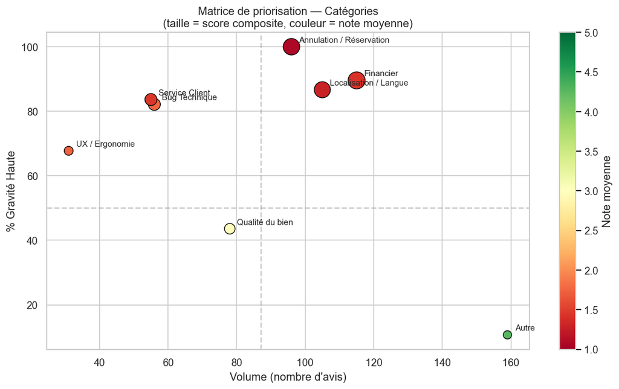

```
Classement par score de priorité (volume × % gravité haute) :
```

| Catégorie | Volume | % Haute | Note moy. | Score priorité |
| --- | --- | --- | --- | --- |
| Financier | 115 | 89.57 | 1.42 | 103 |
| Annulation / Réservation | 96 | 100 | 1.07 | 96 |
| Localisation / Langue | 105 | 86.67 | 1.29 | 91 |
| Bug Technique | 56 | 82.14 | 1.75 | 46 |
| Service Client | 55 | 83.64 | 1.45 | 46 |
| Qualité du bien | 78 | 43.59 | 2.97 | 34 |
| UX / Ergonomie | 31 | 67.74 | 1.74 | 21 |
| Autre | 159 | 10.69 | 4.27 | 17 |

```python
# Construire la table de priorisation
prio = (
    df.groupby("Catégorie")
    .agg(
        volume=("note", "size"),
        note_moyenne=("note", "mean"),
        pct_haute=("Gravité", lambda s: 100 * (s == "Haute").sum() / len(s)),
    )
    .round(2)
)

prio["score"] = (prio["volume"] * prio["pct_haute"] / 100).round(1)
prio = prio.sort_values("score", ascending=False)

# Scatter plot
fig, ax = plt.subplots(figsize=(10, 6))
scatter = ax.scatter(
    prio["volume"],
    prio["pct_haute"],
    s=prio["score"] * 3 + 30,
    c=prio["note_moyenne"],
    cmap="RdYlGn",
    edgecolors="black",
    linewidth=0.8,
    vmin=1,
    vmax=5,
)
for cat, row in prio.iterrows():
    ax.annotate(
        cat,
        (row["volume"], row["pct_haute"]),
        textcoords="offset points",
        xytext=(8, 5),
        fontsize=9,
    )
ax.set_xlabel("Volume (nombre d'avis)")
ax.set_ylabel("% Gravité Haute")
ax.set_title(
    "Matrice de priorisation — Catégories\n(taille = score composite, couleur = note moyenne)"
)
cbar = plt.colorbar(scatter, ax=ax)
cbar.set_label("Note moyenne")
ax.axhline(50, color="gray", linestyle="--", alpha=0.4)
ax.axvline(prio["volume"].median(), color="gray", linestyle="--", alpha=0.4)
plt.tight_layout()
plt.show()

# Classement actionnable
prio_display = prio[["volume", "pct_haute", "note_moyenne", "score"]].copy()
prio_display.columns = ["Volume", "% Haute", "Note moy.", "Score priorité"]
print("Classement par score de priorité (volume × % gravité haute) :")
display(prio_display)
```

## 16. Exports pour Power BI (optionnel)

Fichiers dérivés dans `data/` :

- `synthese_categories.csv` : une ligne par catégorie avec effectif et %.
- `crosstab_categorie_gravite.csv` : effectifs croisés (sans marges).

Tu peux aussi **uniquement** connecter Power BI à `avis_enrichis.csv` et recréer les mesures DAX à partir de la section 3.

```python
out_dir = Path("data")
out_dir.mkdir(parents=True, exist_ok=True)

synthese_path = out_dir / "synthese_categories.csv"
crosstab_path = out_dir / "crosstab_categorie_gravite.csv"

synthese = pd.DataFrame(
    {
        "Catégorie": cat_sorted.index,
        "Effectif": cat_sorted.values,
        "pct_total": (100 * cat_sorted.values / N).round(4),
        "pct_cumule": cum_pct.values,
    }
)

synthese.to_csv(synthese_path, index=False, encoding="utf-8")
ct_body.to_csv(crosstab_path, encoding="utf-8")

# Affichage volontairement relatif au repo (réplicable si le dossier est déplacé/renommé)
print("Écrit :", synthese_path.as_posix())
print("Écrit :", crosstab_path.as_posix())
```

```
Écrit : data/synthese_categories.csv
Écrit : data/crosstab_categorie_gravite.csv
```

## 17. Limites méthodologiques

1. **Échantillon** : les avis reflètent ce que les sources renvoient au moment de la collecte ; ce n'est pas un historique exhaustif.
2. **Catégorisation lexicale** : règles par mots-clés → erreurs possibles (faux positifs / faux négatifs) et thématiques non couvertes regroupées dans « Autre ».
3. **Gravité** : heuristique (mots forts + note + catégorie) ; ne remplace pas une revue qualitative sur un sous-ensemble.
4. **Causalité** : les corrélations (temporelles ou Spearman) n'impliquent pas un lien causal.
5. **Tests statistiques** : les effectifs par cellule sont parfois faibles (< 5), ce qui peut affecter la fiabilité du test χ².

**Reproductibilité** : les exports et indicateurs ci-dessus sont calculés à partir de `data/avis_enrichis.csv` avec les mêmes définitions que celles utilisées dans Power BI.